# Project: Investigate TMDB Dataset

- Introduction
- Data Wrangling
- Exploratory Data Analysis
- Conclusions

## Introduction

For this Data Analyst project, I selected the TMDB Dataset to investigate.

### **Question Researched**:

1. What is the affect of runtime over popularity?
2. Film count changes over year?
3. Movie Popularity over year
4. Genres Popularity over year?
5. Which genres are most popular from year to year
6. Mean Revenues for All Genres
7. What is the correlation for revenue and budget together on popularity

## Data Wrangling

### General Properties

Lets load required libraries

```python
import numpy as np
import pandas as pd
import matplotlib.pyplot as plt
import seaborn as sns


% matplotlib inline
```

Lets load TMDB Movies CSV file and look for first five rows

```python
df = pd.read_csv('tmdb-movies.csv')
df.head()
```

|  | id | imdb_id | popularity | budget | revenue | original_title | cast | homepage | director | tagline | ... | overview | runtime | genres | production_companies | release_date | vote_count | vote_average | release_year | budget_adj | revenue_adj |
| --- | --- | --- | --- | --- | --- | --- | --- | --- | --- | --- | --- | --- | --- | --- | --- | --- | --- | --- | --- | --- | --- |
| 0 | 135397 | tt0369610 | 32.985763 | 150000000 | 1513528810 | Jurassic World | Chris Pratt\|Bryce Dallas Howard\|Irrfan Khan\|Vi... | http://www.jurassicworld.com/ | Colin Trevorrow | The park is open. | ... | Twenty-two years after the events of Jurassic ... | 124 | Action\|Adventure\|Science Fiction\|Thriller | Universal Studios\|Amblin Entertainment\|Legenda... | 6/9/15 | 5562 | 6.5 | 2015 | 1.379999e+08 | 1.392446e+09 |
| 1 | 76341 | tt1392190 | 28.419936 | 150000000 | 378436354 | Mad Max: Fury Road | Tom Hardy\|Charlize Theron\|Hugh Keays-Byrne\|Nic... | http://www.madmaxmovie.com/ | George Miller | What a Lovely Day. | ... | An apocalyptic story set in the furthest reach... | 120 | Action\|Adventure\|Science Fiction\|Thriller | Village Roadshow Pictures\|Kennedy Miller Produ... | 5/13/15 | 6185 | 7.1 | 2015 | 1.379999e+08 | 3.481613e+08 |
| 2 | 262500 | tt2908446 | 13.112507 | 110000000 | 295238201 | Insurgent | Shailene Woodley\|Theo James\|Kate Winslet\|Ansel... | http://www.thedivergentseries.movie/#insurgent | Robert Schwentke | One Choice Can Destroy You | ... | Beatrice Prior must confront her inner demons ... | 119 | Adventure\|Science Fiction\|Thriller | Summit Entertainment\|Mandeville Films\|Red Wago... | 3/18/15 | 2480 | 6.3 | 2015 | 1.012000e+08 | 2.716190e+08 |
| 3 | 140607 | tt2488496 | 11.173104 | 200000000 | 2068178225 | Star Wars: The Force Awakens | Harrison Ford\|Mark Hamill\|Carrie Fisher\|Adam D... | http://www.starwars.com/films/star-wars-episod... | J.J. Abrams | Every generation has a story. | ... | Thirty years after defeating the Galactic Empi... | 136 | Action\|Adventure\|Science Fiction\|Fantasy | Lucasfilm\|Truenorth Productions\|Bad Robot | 12/15/15 | 5292 | 7.5 | 2015 | 1.839999e+08 | 1.902723e+09 |
| 4 | 168259 | tt2820852 | 9.335014 | 190000000 | 1506249360 | Furious 7 | Vin Diesel\|Paul Walker\|Jason Statham\|Michelle ... | http://www.furious7.com/ | James Wan | Vengeance Hits Home | ... | Deckard Shaw seeks revenge against Dominic Tor... | 137 | Action\|Crime\|Thriller | Universal Pictures\|Original Film\|Media Rights ... | 4/1/15 | 2947 | 7.3 | 2015 | 1.747999e+08 | 1.385749e+09 |

5 rows × 21 columns

```python
df.shape
```

```
(10866, 21)
```

The DataFrame has 10.866 rows and 21 columns

```python
df.info()
```

```
<class 'pandas.core.frame.DataFrame'>
RangeIndex: 10866 entries, 0 to 10865
Data columns (total 21 columns):
id                      10866 non-null int64
imdb_id                 10856 non-null object
popularity              10866 non-null float64
budget                  10866 non-null int64
revenue                 10866 non-null int64
original_title          10866 non-null object
cast                    10790 non-null object
homepage                2936 non-null object
director                10822 non-null object
tagline                 8042 non-null object
keywords                9373 non-null object
overview                10862 non-null object
runtime                 10866 non-null int64
genres                  10843 non-null object
production_companies    9836 non-null object
release_date            10866 non-null object
vote_count              10866 non-null int64
vote_average            10866 non-null float64
release_year            10866 non-null int64
budget_adj              10866 non-null float64
revenue_adj             10866 non-null float64
dtypes: float64(4), int64(6), object(11)
memory usage: 1.7+ MB
```

The dataset has some null value in the cast, director, overview and genres columns. Also some columns like `homepage`, `tagline`, `keywords` and `production_companies` columns are not necessary for answering my questions, so I decide to drop columns.

Lets see some statistcs on data

```python
df.describe()
```

|  | id | popularity | budget | revenue | runtime | vote_count | vote_average | release_year | budget_adj | revenue_adj |
| --- | --- | --- | --- | --- | --- | --- | --- | --- | --- | --- |
| count | 10866.000000 | 10866.000000 | 1.086600e+04 | 1.086600e+04 | 10866.000000 | 10866.000000 | 10866.000000 | 10866.000000 | 1.086600e+04 | 1.086600e+04 |
| mean | 66064.177434 | 0.646441 | 1.462570e+07 | 3.982332e+07 | 102.070863 | 217.389748 | 5.974922 | 2001.322658 | 1.755104e+07 | 5.136436e+07 |
| std | 92130.136561 | 1.000185 | 3.091321e+07 | 1.170035e+08 | 31.381405 | 575.619058 | 0.935142 | 12.812941 | 3.430616e+07 | 1.446325e+08 |
| min | 5.000000 | 0.000065 | 0.000000e+00 | 0.000000e+00 | 0.000000 | 10.000000 | 1.500000 | 1960.000000 | 0.000000e+00 | 0.000000e+00 |
| 25% | 10596.250000 | 0.207583 | 0.000000e+00 | 0.000000e+00 | 90.000000 | 17.000000 | 5.400000 | 1995.000000 | 0.000000e+00 | 0.000000e+00 |
| 50% | 20669.000000 | 0.383856 | 0.000000e+00 | 0.000000e+00 | 99.000000 | 38.000000 | 6.000000 | 2006.000000 | 0.000000e+00 | 0.000000e+00 |
| 75% | 75610.000000 | 0.713817 | 1.500000e+07 | 2.400000e+07 | 111.000000 | 145.750000 | 6.600000 | 2011.000000 | 2.085325e+07 | 3.369710e+07 |
| max | 417859.000000 | 32.985763 | 4.250000e+08 | 2.781506e+09 | 900.000000 | 9767.000000 | 9.200000 | 2015.000000 | 4.250000e+08 | 2.827124e+09 |

looks like we home lots of zero values on `budget`, `revenue`, `budget_adj` and `revenur_adj` columns. I will not use `budget_adj` and `revenur_adj` columns on any analysis. So will drop these columns as well.  
Also lets investigate why `budget` and `revenue` columns has lots of zero values.

```python
print(len(df[df['budget'] == 0]))
print(len(df[df['revenue'] == 0]))
```

```
5696
6016
```

```python
df[df.budget == 0].head(2)
```

|  | id | imdb_id | popularity | budget | revenue | original_title | cast | homepage | director | tagline | ... | overview | runtime | genres | production_companies | release_date | vote_count | vote_average | release_year | budget_adj | revenue_adj |
| --- | --- | --- | --- | --- | --- | --- | --- | --- | --- | --- | --- | --- | --- | --- | --- | --- | --- | --- | --- | --- | --- |
| 30 | 280996 | tt3168230 | 3.927333 | 0 | 29355203 | Mr. Holmes | Ian McKellen\|Milo Parker\|Laura Linney\|Hattie M... | http://www.mrholmesfilm.com/ | Bill Condon | The man behind the myth | ... | The story is set in 1947, following a long-ret... | 103 | Mystery\|Drama | BBC Films\|See-Saw Films\|FilmNation Entertainme... | 6/19/15 | 425 | 6.4 | 2015 | 0.0 | 2.700677e+07 |
| 36 | 339527 | tt1291570 | 3.358321 | 0 | 22354572 | Solace | Abbie Cornish\|Jeffrey Dean Morgan\|Colin Farrel... | NaN | Afonso Poyart | A serial killer who can see your future, a psy... | ... | A psychic doctor, John Clancy, works with an F... | 101 | Crime\|Drama\|Mystery | Eden Rock Media\|FilmNation Entertainment\|Flynn... | 9/3/15 | 474 | 6.2 | 2015 | 0.0 | 2.056620e+07 |

2 rows × 21 columns

I just thought that the budget of old movies would be 0. But we can see above rows `release_year`are 2015. But I still want to check.

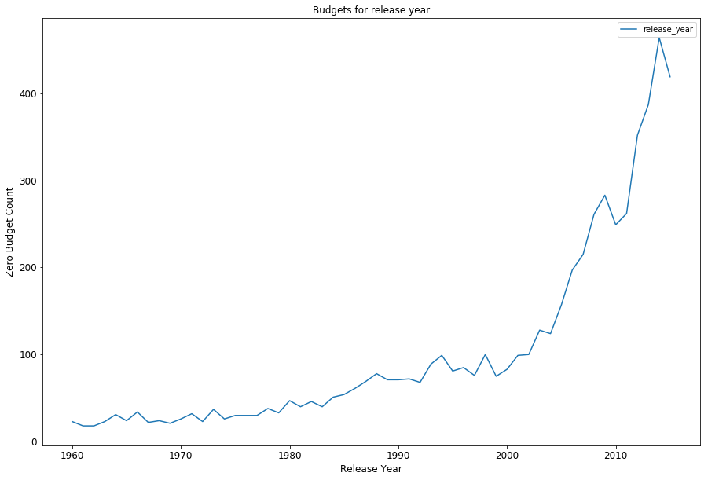

```python
#lets look zero butgets & release_year relation
ax = df[df.budget == 0].release_year.value_counts().sort_index().plot(kind='line', title ="Budgets for release year", figsize=(15, 10), legend=True, fontsize=12)
ax.set_xlabel("Release Year", fontsize=12)
ax.set_ylabel("Zero Budget Count", fontsize=12)
plt.show()
```

Nope. So we need these columns and also we can't drop zero value rows because it will reduce the number of data too much. For keep data integrity, I will replace zero values to null values on `budget` and `revenue`columns.

Lets see the count of empty rows for `director`, `cast`, `production_companies` and `genres` columns.

```python
df.isnull().sum()
```

```
id                         0
imdb_id                   10
popularity                 0
budget                     0
revenue                    0
original_title             0
cast                      76
homepage                7930
director                  44
tagline                 2824
keywords                1493
overview                   4
runtime                    0
genres                    23
production_companies    1030
release_date               0
vote_count                 0
vote_average               0
release_year               0
budget_adj                 0
revenue_adj                0
dtype: int64
```

`director`, `cast`, `production_companies` and `genres` columns have a few null rows. So we can drop nulls for this.

And better we check for duplicate rows

```python
df.duplicated().sum()
```

```
1
```

Looks like we have 1 duplicate row. Lets see:

```python
df[df.duplicated()]
```

|  | id | imdb_id | popularity | budget | revenue | original_title | cast | homepage | director | tagline | ... | overview | runtime | genres | production_companies | release_date | vote_count | vote_average | release_year | budget_adj | revenue_adj |
| --- | --- | --- | --- | --- | --- | --- | --- | --- | --- | --- | --- | --- | --- | --- | --- | --- | --- | --- | --- | --- | --- |
| 2090 | 42194 | tt0411951 | 0.59643 | 30000000 | 967000 | TEKKEN | Jon Foo\|Kelly Overton\|Cary-Hiroyuki Tagawa\|Ian... | NaN | Dwight H. Little | Survival is no game | ... | In the year of 2039, after World Wars destroy ... | 92 | Crime\|Drama\|Action\|Thriller\|Science Fiction | Namco\|Light Song Films | 3/20/10 | 110 | 5.0 | 2010 | 30000000.0 | 967000.0 |

1 rows × 21 columns

```python
df.query('original_title == "TEKKEN"')
```

|  | id | imdb_id | popularity | budget | revenue | original_title | cast | homepage | director | tagline | ... | overview | runtime | genres | production_companies | release_date | vote_count | vote_average | release_year | budget_adj | revenue_adj |
| --- | --- | --- | --- | --- | --- | --- | --- | --- | --- | --- | --- | --- | --- | --- | --- | --- | --- | --- | --- | --- | --- |
| 2089 | 42194 | tt0411951 | 0.59643 | 30000000 | 967000 | TEKKEN | Jon Foo\|Kelly Overton\|Cary-Hiroyuki Tagawa\|Ian... | NaN | Dwight H. Little | Survival is no game | ... | In the year of 2039, after World Wars destroy ... | 92 | Crime\|Drama\|Action\|Thriller\|Science Fiction | Namco\|Light Song Films | 3/20/10 | 110 | 5.0 | 2010 | 30000000.0 | 967000.0 |
| 2090 | 42194 | tt0411951 | 0.59643 | 30000000 | 967000 | TEKKEN | Jon Foo\|Kelly Overton\|Cary-Hiroyuki Tagawa\|Ian... | NaN | Dwight H. Little | Survival is no game | ... | In the year of 2039, after World Wars destroy ... | 92 | Crime\|Drama\|Action\|Thriller\|Science Fiction | Namco\|Light Song Films | 3/20/10 | 110 | 5.0 | 2010 | 30000000.0 | 967000.0 |

2 rows × 21 columns

Also runtime column has zero values.

```python
df[df['runtime'] == 0].head()
```

|  | id | imdb_id | popularity | budget | revenue | original_title | cast | homepage | director | tagline | ... | overview | runtime | genres | production_companies | release_date | vote_count | vote_average | release_year | budget_adj | revenue_adj |
| --- | --- | --- | --- | --- | --- | --- | --- | --- | --- | --- | --- | --- | --- | --- | --- | --- | --- | --- | --- | --- | --- |
| 92 | 370687 | tt3608646 | 1.876037 | 0 | 0 | Mythica: The Necromancer | Melanie Stone\|Adam Johnson\|Kevin Sorbo\|Nicola ... | http://www.mythicamovie.com/#!blank/y9ake | A. Todd Smith | NaN | ... | Mallister takes Thane prisoner and forces Mare... | 0 | Fantasy\|Action\|Adventure | Arrowstorm Entertainment\|Camera 40 Productions... | 12/19/15 | 11 | 5.4 | 2015 | 0.0 | 0.0 |
| 334 | 361931 | tt5065822 | 0.357654 | 0 | 0 | Ronaldo | Cristiano Ronaldo | http://www.ronaldothefilm.com | Anthony Wonke | Astonishing. Intimate. Definitive. | ... | Filmed over 14 months with unprecedented acces... | 0 | Documentary | On The Corner Films\|We Came, We Saw, We Conque... | 11/9/15 | 80 | 6.5 | 2015 | 0.0 | 0.0 |
| 410 | 339342 | tt2948712 | 0.097514 | 0 | 0 | Anarchy Parlor | Robert LaSardo\|Jordan James Smith\|Sara Fabel\|T... | NaN | Kenny Gage\|Devon Downs | NaN | ... | Six young college hopefuls vacationing and par... | 0 | Horror | NaN | 1/1/15 | 15 | 5.6 | 2015 | 0.0 | 0.0 |
| 445 | 353345 | tt3800796 | 0.218528 | 0 | 0 | The Exorcism of Molly Hartley | Sarah Lind\|Devon Sawa\|Gina Holden\|Peter MacNei... | NaN | Steven R. Monroe | NaN | ... | Taking place years after The Haunting of Molly... | 0 | Horror | WT Canada Productions | 10/9/15 | 52 | 5.0 | 2015 | 0.0 | 0.0 |
| 486 | 333653 | tt4058368 | 0.176744 | 0 | 0 | If There Be Thorns | Heather Graham\|Jason Lewis\|Rachael Carpani\|Mas... | NaN | Nancy Savoca | NaN | ... | The third installment in V.C. Andrewsâ€™ bests... | 0 | TV Movie\|Drama | A+E Studios\|Jane Startz Productions | 4/5/15 | 11 | 5.4 | 2015 | 0.0 | 0.0 |

5 rows × 21 columns

### Data Cleaning

1. Drop unnecessary columns : `tagline`, `keywords`, `homepage`, `tagline`, `imdb_id`, `overview`,`budget_adj`, `revenue_adj`.
2. Drop null value rows for: `production_companies`, `cast`, `director`, and `genres`.
3. Replace zero values with null for : `budget` and `revenue` columns.
4. Drop duplicates.
5. Replacing zero with NAN in runtime column.

##### Drop unnecessary columns

```python
#drop columns with inplace
df.drop(['tagline', 'imdb_id', 'homepage', 'tagline', 'overview', 'keywords', 'budget_adj', 'revenue_adj'], axis=1, inplace=True)
```

##### Drop null value for columns

```python
df.dropna(subset=['director','genres', 'production_companies','cast'], inplace=True)
```

##### Replace zero values with null

```python
df['budget'] = df['budget'].replace(0, np.NaN)
df['revenue'] = df['revenue'].replace(0, np.NaN)
```

I now that, this operation will effect efficiency bad. But we can not fill zero values with any of the methods we have learned.

##### Drop duplicates

```python
df.drop_duplicates(keep='first', inplace=True)
```

##### Replacing zero with NAN in runtime column.

```python
df['runtime'] = df['runtime'].replace(0, np.NaN)
```

Lets look to the dataset

```python
df.describe()
```

|  | id | popularity | budget | revenue | runtime | vote_count | vote_average | release_year |
| --- | --- | --- | --- | --- | --- | --- | --- | --- |
| count | 9772.000000 | 9772.000000 | 5.021000e+03 | 4.750000e+03 | 9759.000000 | 9772.000000 | 9772.000000 | 9772.000000 |
| mean | 63189.640810 | 0.694721 | 3.148929e+07 | 9.099524e+07 | 103.063736 | 239.312014 | 5.963528 | 2000.878428 |
| std | 90718.059987 | 1.036931 | 3.920818e+07 | 1.632905e+08 | 27.641529 | 603.011504 | 0.913174 | 13.036794 |
| min | 5.000000 | 0.000188 | 1.000000e+00 | 2.000000e+00 | 3.000000 | 10.000000 | 1.500000 | 1960.000000 |
| 25% | 10221.500000 | 0.232710 | 6.300000e+06 | 8.501551e+06 | 91.000000 | 18.000000 | 5.400000 | 1994.000000 |
| 50% | 18677.500000 | 0.419762 | 1.800000e+07 | 3.331677e+07 | 100.000000 | 46.000000 | 6.000000 | 2005.000000 |
| 75% | 70577.250000 | 0.776408 | 4.000000e+07 | 1.015876e+08 | 112.000000 | 173.000000 | 6.600000 | 2011.000000 |
| max | 417859.000000 | 32.985763 | 4.250000e+08 | 2.781506e+09 | 877.000000 | 9767.000000 | 8.700000 | 2015.000000 |

```python
df.info()
```

```
<class 'pandas.core.frame.DataFrame'>
Int64Index: 9772 entries, 0 to 10865
Data columns (total 14 columns):
id                      9772 non-null int64
popularity              9772 non-null float64
budget                  5021 non-null float64
revenue                 4750 non-null float64
original_title          9772 non-null object
cast                    9772 non-null object
director                9772 non-null object
runtime                 9759 non-null float64
genres                  9772 non-null object
production_companies    9772 non-null object
release_date            9772 non-null object
vote_count              9772 non-null int64
vote_average            9772 non-null float64
release_year            9772 non-null int64
dtypes: float64(5), int64(3), object(6)
memory usage: 1.1+ MB
```

Looks great!

## Exploratory Data Analysis

### Question 1 : What is the affect of runtime over popularity?

First, lets draw a line chart, including runtime and popularity

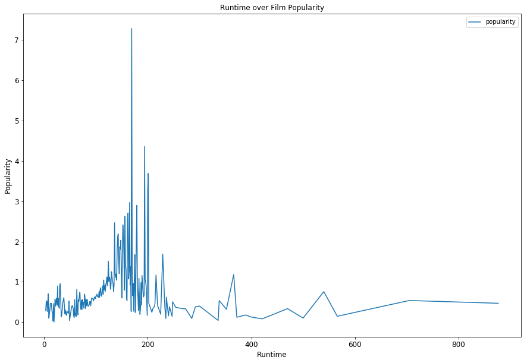

```python
ax = df.groupby('runtime').popularity.mean().plot(kind='line', title ="Runtime over Film Popularity", figsize=(15, 10), legend=True, fontsize=12)
ax.set_xlabel("Runtime", fontsize=12)
ax.set_ylabel("Popularity", fontsize=12)
plt.show()
```

Lets smooth the chart with moving-average

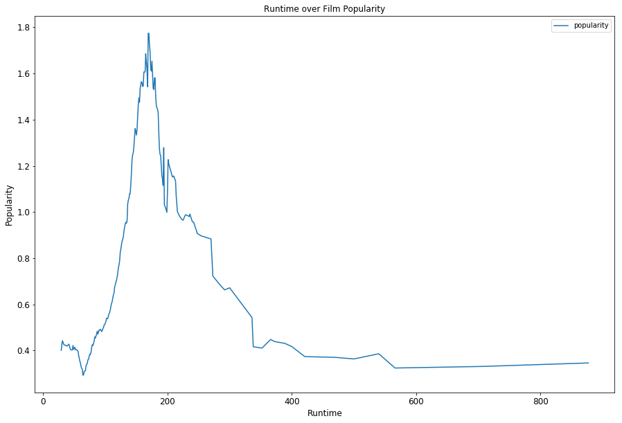

```python
ax = df.groupby('runtime').popularity.mean().rolling(window=25).mean().plot(kind='line', title ="Runtime over Film Popularity", figsize=(15, 10), legend=True, fontsize=12)
ax.set_xlabel("Runtime", fontsize=12)
ax.set_ylabel("Popularity", fontsize=12)
plt.show()
```

Lets see with box-blot

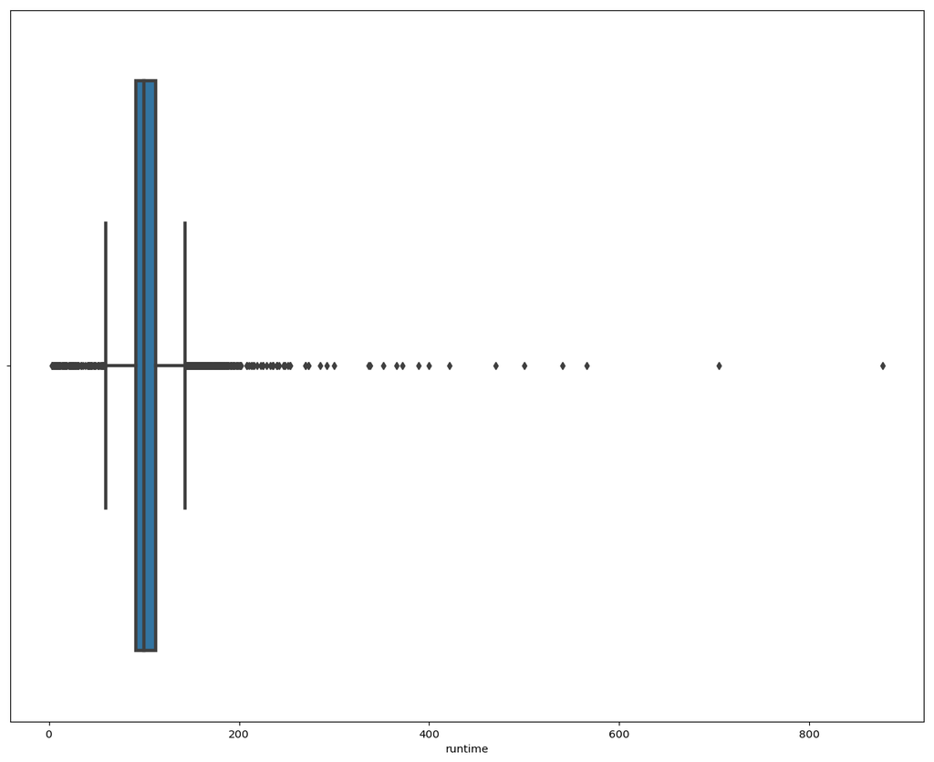

```python
plt.figure(figsize=(15,12), dpi = 107)
sns.boxplot(df.groupby('popularity').runtime.mean(), linewidth = 3)
plt.show()
```

### Question 2 : Film count changes over year?

First lets find year - film count values

```python
df['release_year'].value_counts().head()
```

```
2014    635
2013    567
2015    558
2012    498
2009    474
Name: release_year, dtype: int64
```

As we can see the column values not sorted. So lets sort and see as bar chart

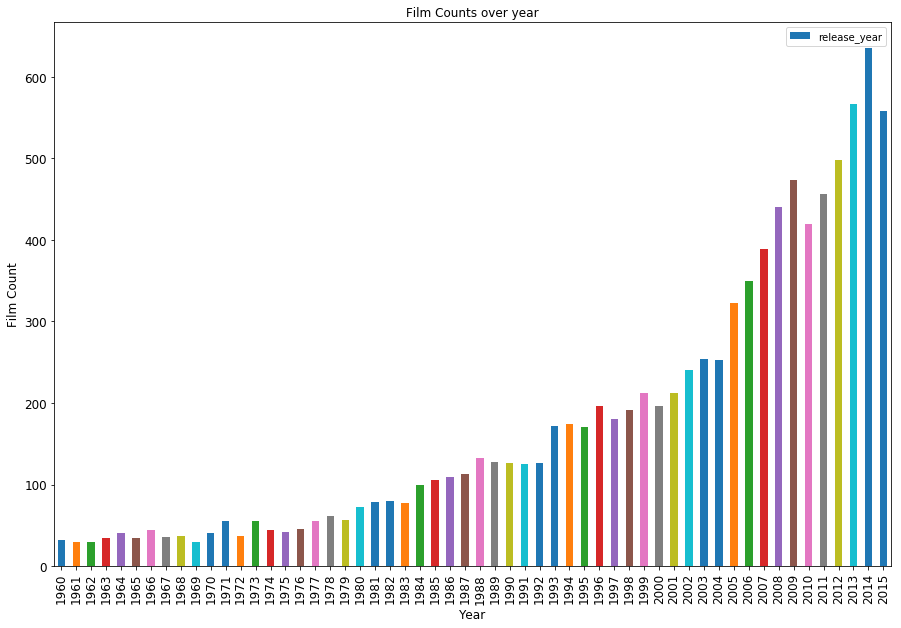

```python
ax = df['release_year'].value_counts().sort_index().plot(kind='bar', title ="Film Counts over year", figsize=(15, 10), legend=True, fontsize=12)
ax.set_xlabel("Year", fontsize=12)
ax.set_ylabel("Film Count", fontsize=12)
plt.show()
```

### Question 3 : Movie Popularity over year

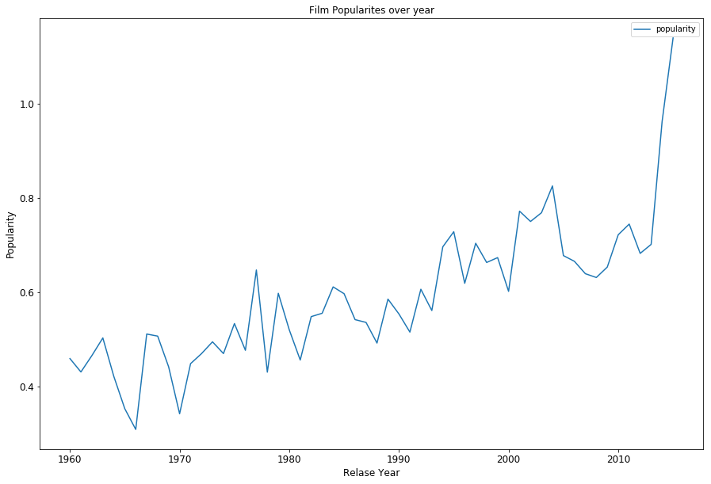

```python
ax = df.groupby('release_year').popularity.mean().plot(kind='line', title ="Film Popularites over year", figsize=(15, 10), legend=True, fontsize=12)
ax.set_xlabel("Relase Year", fontsize=12)
ax.set_ylabel("Popularity", fontsize=12)
plt.show()
```

### Question 4 : Genres Popularity over year?

First we need to split apart to new columns genres values

```python
# expand string based on delimiter ("|")
expand_str = df["genres"].str.split('|', expand=True)
dummies_df = pd.get_dummies(expand_str.stack(dropna=False)).sum(level=0).add_prefix("genres_")
df = pd.concat([df, dummies_df], axis=1, join_axes=[df.index])
```

Lets see the new created columns for genres

```python
df[df.columns[pd.Series(df.columns).str.startswith('genres_')]].head()
```

|  | genres_Action | genres_Adventure | genres_Animation | genres_Comedy | genres_Crime | genres_Documentary | genres_Drama | genres_Family | genres_Fantasy | genres_Foreign | genres_History | genres_Horror | genres_Music | genres_Mystery | genres_Romance | genres_Science Fiction | genres_TV Movie | genres_Thriller | genres_War | genres_Western |
| --- | --- | --- | --- | --- | --- | --- | --- | --- | --- | --- | --- | --- | --- | --- | --- | --- | --- | --- | --- | --- |
| 0 | 1 | 1 | 0 | 0 | 0 | 0 | 0 | 0 | 0 | 0 | 0 | 0 | 0 | 0 | 0 | 1 | 0 | 1 | 0 | 0 |
| 1 | 1 | 1 | 0 | 0 | 0 | 0 | 0 | 0 | 0 | 0 | 0 | 0 | 0 | 0 | 0 | 1 | 0 | 1 | 0 | 0 |
| 2 | 0 | 1 | 0 | 0 | 0 | 0 | 0 | 0 | 0 | 0 | 0 | 0 | 0 | 0 | 0 | 1 | 0 | 1 | 0 | 0 |
| 3 | 1 | 1 | 0 | 0 | 0 | 0 | 0 | 0 | 1 | 0 | 0 | 0 | 0 | 0 | 0 | 1 | 0 | 0 | 0 | 0 |
| 4 | 1 | 0 | 0 | 0 | 1 | 0 | 0 | 0 | 0 | 0 | 0 | 0 | 0 | 0 | 0 | 0 | 0 | 1 | 0 | 0 |

This columns will be very helpful to us for further analysis  
Lets try to virtualize one genres over year

```python
min_year = df['release_year'].min()
max_year = df['release_year'].max()

current_year = min_year

while True:
    print("Year : {} -- Popularity : {}".format(current_year, df[(df['genres_Horror'] == True) & (df.release_year == current_year)].popularity.mean()))
    current_year = current_year + 1
    if max_year == current_year:
        break
```

```
Year : 1960 -- Popularity : 0.5914495714285711
Year : 1961 -- Popularity : 0.25457766666666665
Year : 1962 -- Popularity : 0.17936760000000002
Year : 1963 -- Popularity : 0.3769011111111101
Year : 1964 -- Popularity : 0.18965033333333314
Year : 1965 -- Popularity : 0.15485499999999996
Year : 1966 -- Popularity : 0.09439666666666667
Year : 1967 -- Popularity : 0.28996425000000003
Year : 1968 -- Popularity : 0.5584034999999999
Year : 1969 -- Popularity : 0.141028
Year : 1970 -- Popularity : 0.2731444
Year : 1971 -- Popularity : 0.1747421428571429
Year : 1972 -- Popularity : 0.18759612500000003
Year : 1973 -- Popularity : 0.4195435999999999
Year : 1974 -- Popularity : 0.30520687500000004
Year : 1975 -- Popularity : 0.6702267499999989
Year : 1976 -- Popularity : 0.43229177777777766
Year : 1977 -- Popularity : 0.18538328571428567
Year : 1978 -- Popularity : 0.38921010526315775
Year : 1979 -- Popularity : 0.7313126363636363
Year : 1980 -- Popularity : 0.44698199999999993
Year : 1981 -- Popularity : 0.3096619166666666
Year : 1982 -- Popularity : 0.4532765499999999
Year : 1983 -- Popularity : 0.41241174999999997
Year : 1984 -- Popularity : 0.4872105555555556
Year : 1985 -- Popularity : 0.5245750714285714
Year : 1986 -- Popularity : 0.4796737199999999
Year : 1987 -- Popularity : 0.4804209130434782
Year : 1988 -- Popularity : 0.35027794117647065
Year : 1989 -- Popularity : 0.37149656
Year : 1990 -- Popularity : 0.5083664799999997
Year : 1991 -- Popularity : 0.38817781818181823
Year : 1992 -- Popularity : 0.615679125
Year : 1993 -- Popularity : 0.3512658235294117
Year : 1994 -- Popularity : 0.5270877692307692
Year : 1995 -- Popularity : 0.48829994736842086
Year : 1996 -- Popularity : 0.5080398823529412
Year : 1997 -- Popularity : 0.777630888888889
Year : 1998 -- Popularity : 0.6314301999999998
Year : 1999 -- Popularity : 0.6430723333333328
Year : 2000 -- Popularity : 0.4220301111111111
Year : 2001 -- Popularity : 0.6084158499999999
Year : 2002 -- Popularity : 0.6199200689655173
Year : 2003 -- Popularity : 0.5154365454545456
Year : 2004 -- Popularity : 0.7937506785714287
Year : 2005 -- Popularity : 0.495997214285714
Year : 2006 -- Popularity : 0.4364636666666666
Year : 2007 -- Popularity : 0.6150136184210523
Year : 2008 -- Popularity : 0.32966429577464784
Year : 2009 -- Popularity : 0.45740702352941165
Year : 2010 -- Popularity : 0.4615317313432835
Year : 2011 -- Popularity : 0.45478130882352946
Year : 2012 -- Popularity : 0.4632493695652171
Year : 2013 -- Popularity : 0.5263531630434783
Year : 2014 -- Popularity : 0.5049042959183674
```

So we can get popularity on year and genres. But how can we simplify the code and show as a chart

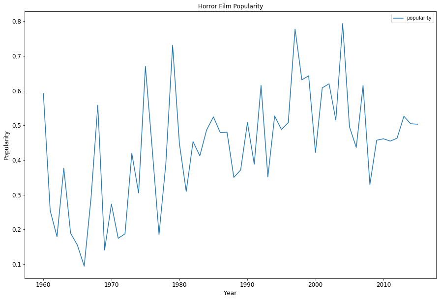

```python
ax = df[(df['genres_Horror'] == True)].groupby('release_year').popularity.mean().plot(kind='line', title ="Horror Film Popularity", figsize=(15, 10), legend=True, fontsize=12)
ax.set_xlabel("Year", fontsize=12)
ax.set_ylabel("Popularity", fontsize=12)
plt.show()
```

Now can we show all genre types in one chart?  
Lets try!

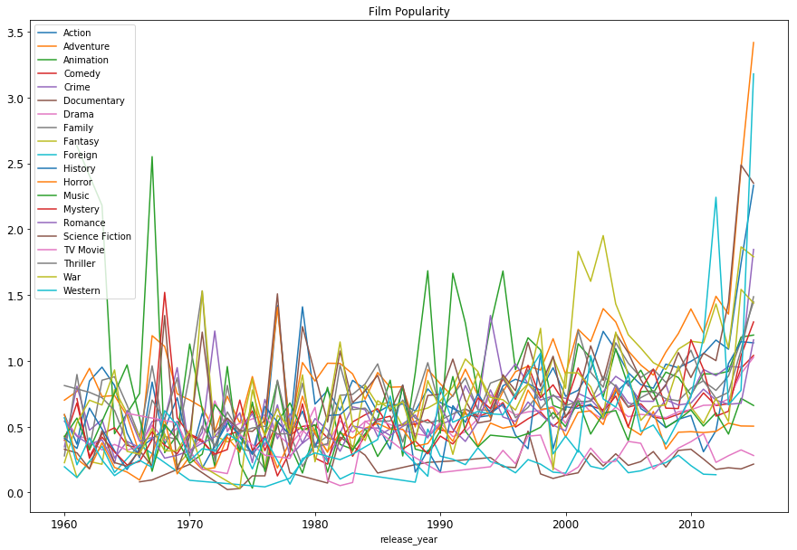

```python
for str in df.columns:
    if str.startswith('genres_'):
        df[(df[str] == True)].groupby('release_year').popularity.mean().plot(kind='line', title ="Film Popularity", figsize=(15, 10), legend=True, fontsize=12, label=str.replace("genres_",""))
```

Chart has lots of value to display. Lets try to look for last 10 years

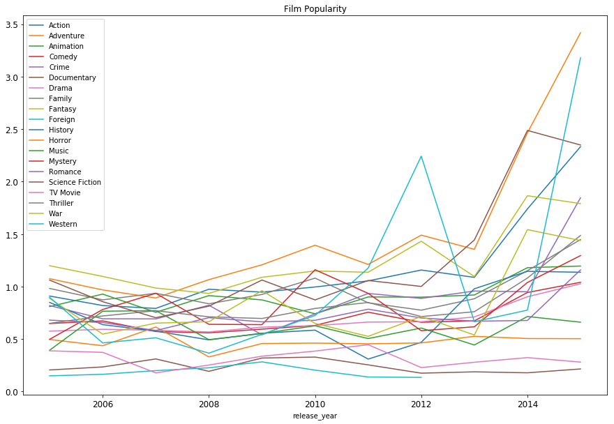

```python
df_last_ten_years = df[df.release_year > 2004]
for str in df_last_ten_years.columns:
    if str.startswith('genres_'):
        df_last_ten_years[(df_last_ten_years[str] == True)].groupby('release_year').popularity.mean().plot(kind='line', title ="Film Popularity", figsize=(15, 10), legend=True, fontsize=12, label=str.replace("genres_",""))
```

### Question 5 : Which genres are most popular from year to year

we can get mean of a genres and a year like below

```python
df[(df.release_year == 2014) & (df.genres_Horror == True)].popularity.mean()
```

```
0.5049042959183674
```

```python
for str in df.columns:
    if str.startswith('genres_'):
        print(40*'-')
        print(str)
        print(df[(df[str] == True)].groupby('release_year').popularity.mean())
        #lets not print all of them
        break
```

```
----------------------------------------
genres_Action
release_year
1960    0.590724
1961    0.365913
1962    0.845972
1963    0.951729
1964    0.813087
1965    0.451373
1966    0.263347
1967    0.838468
1968    0.365562
1969    0.539976
1970    0.241650
1971    0.600479
```

[output cut: 45 more lines]

```python
#first get unique years, sort them and create new dataframe
year_list=pd.Series(df.release_year.unique()).sort_values(ascending=True)
newdf = pd.DataFrame(index=year_list)

#later we can create each genres populartion avg over years
for str in df.columns:
    if str.startswith('genres_'):
        #print(40*'-')
        #print(str)
        #print(df[(df[str] == True)].groupby('release_year').popularity.mean())
        newdf[str] = df[(df[str] == True)].groupby('release_year').popularity.mean()
```

```python
newdf.head()
```

|  | genres_Action | genres_Adventure | genres_Animation | genres_Comedy | genres_Crime | genres_Documentary | genres_Drama | genres_Family | genres_Fantasy | genres_Foreign | genres_History | genres_Horror | genres_Music | genres_Mystery | genres_Romance | genres_Science Fiction | genres_TV Movie | genres_Thriller | genres_War | genres_Western |
| --- | --- | --- | --- | --- | --- | --- | --- | --- | --- | --- | --- | --- | --- | --- | --- | --- | --- | --- | --- | --- |
| 1960 | 0.590724 | 0.700981 | NaN | 0.396000 | 0.346480 | NaN | 0.566305 | 0.278064 | 0.428247 | 0.194948 | 0.412364 | 0.591450 | 0.423531 | NaN | 0.541227 | 0.327905 | NaN | 0.811910 | 0.225863 | 0.567759 |
| 1961 | 0.365913 | 0.767323 | 2.631987 | 0.679838 | 0.806519 | NaN | 0.432233 | 0.896028 | 0.113651 | 0.113651 | 0.334463 | 0.254578 | 0.564749 | 0.712793 | 0.426036 | 0.300638 | NaN | NaN | 0.531184 | 0.210021 |
| 1962 | 0.845972 | 0.942513 | NaN | 0.273183 | 0.472816 | NaN | 0.401909 | 0.323463 | 0.235542 | 0.235542 | 0.640491 | 0.179368 | 0.323933 | 0.259220 | 0.365621 | 0.179212 | NaN | 0.760582 | 0.700762 | 0.414180 |
| 1963 | 0.951729 | 0.728487 | 2.180410 | 0.444481 | 0.552367 | NaN | 0.322448 | 0.852632 | 0.214071 | 0.351647 | 0.481618 | 0.376901 | NaN | 0.421033 | 0.399573 | 0.467836 | NaN | 0.719929 | 0.664326 | 0.246957 |
| 1964 | 0.813087 | 0.736431 | 0.445746 | 0.491229 | 0.261690 | NaN | 0.364818 | 0.878298 | 0.780640 | 0.152209 | 0.316377 | 0.189650 | 0.753799 | 0.308091 | 0.221586 | 0.226636 | NaN | 0.622580 | 0.930959 | 0.127679 |

The data looks great. So lets find each years most popular genre.

```python
newdf.idxmax(axis=1)
```

```
1960           genres_Thriller
1961          genres_Animation
1962          genres_Adventure
1963          genres_Animation
1964                genres_War
1965              genres_Music
1966          genres_Animation
1967          genres_Animation
1968            genres_Mystery
1969              genres_Crime
1970          genres_Animation
1971             genres_Family
1972              genres_Crime
1973          genres_Animation
1974            genres_Mystery
```

[output cut: 42 more lines]

Lets see results on a fancy chart

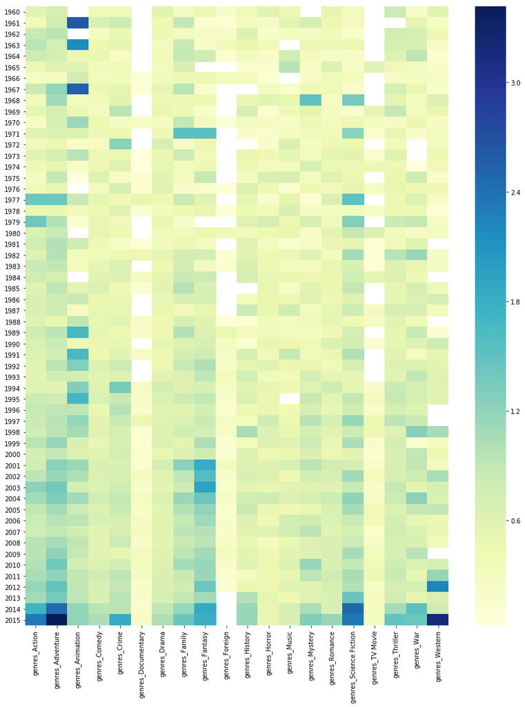

```python
fig, ax = plt.subplots()
fig.set_size_inches(15, 18)
ax = sns.heatmap(newdf, cmap="YlGnBu")
```

### Question 6 : Mean Revenues for All Genres

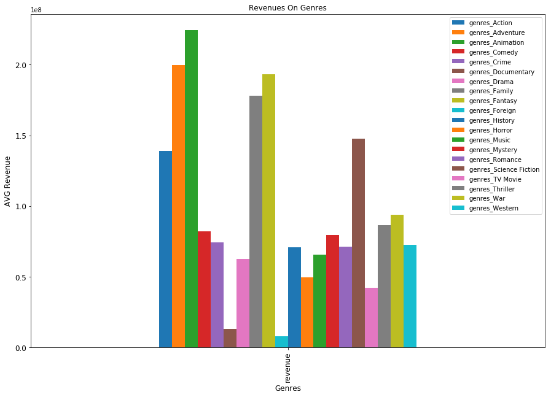

```python
#df[df.columns[pd.Series(df.columns).str.startswith('genres_')]].columns
revenue_df = pd.DataFrame(index=['revenue'])
for str in df.columns:
    if str.startswith('genres_'):
        revenue_df[str]=df[(df[str] == True)].revenue.mean()


ax = revenue_df.plot(kind='bar', title ="Revenues On Genres", figsize=(15, 10), legend=True, fontsize=12)
ax.set_xlabel("Genres", fontsize=12)
ax.set_ylabel("AVG Revenue", fontsize=12)
plt.show()
```

### Question 7 : What is the correlation for revenue and budget together on popularity

First let see the data for `budget`and `revenue`data with group by on `popularity`

```python
df.groupby('popularity')['revenue', 'budget'].mean().rolling(window=10).mean().tail()
```

| popularity | revenue | budget |
| --- | --- | --- |
| 13.112507 | 1.075280e+09 | 147300000.0 |
| 14.311205 | 1.001986e+09 | 145300000.0 |
| 24.949134 | 9.816112e+08 | 145800000.0 |
| 28.419936 | 7.413042e+08 | 137100000.0 |
| 32.985763 | 7.971451e+08 | 127100000.0 |

And lets see both on same chart

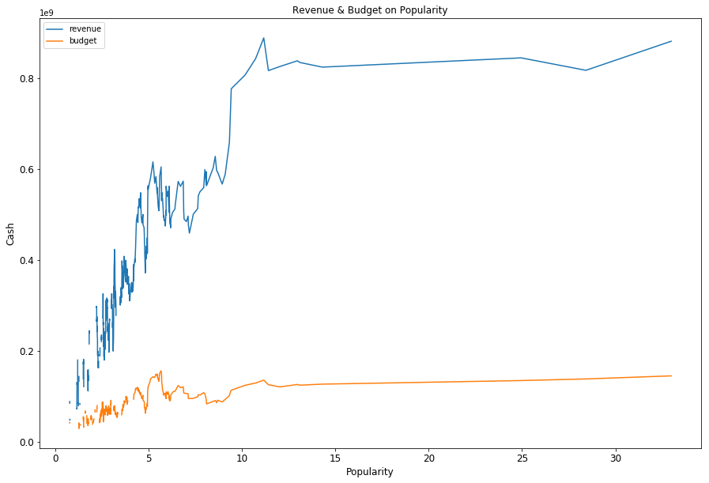

```python
ax = df.groupby('popularity')['revenue', 'budget'].mean().rolling(window=20).mean().plot(kind='line', title ="Revenue & Budget on Popularity", figsize=(15, 10), legend=True, fontsize=12)
ax.set_xlabel("Popularity", fontsize=12)
ax.set_ylabel("Cash", fontsize=12)
plt.show()
```

## Conclusions

> **Question 2 : Film count changes over year?**: We can see that film counts increasing over years. Also We can see a slight decrease in movie counts due to global economic crysis (**[ref](http://www.ifre.com/a-history-of-the-past-40-years-in-financial-crises/21102949.fullarticle)**):
> - the big world economic crisis in 2008/2009.
> - dotcom bubble crisis in 1999/2000.
> - Asia crisis in 1997.

> **Question 3 : Movie Popularity over year** : We can say that the popularity of the movies has increased slowly since 2000 and then increased more rapidly.  
> The most important reason for this may be the exponential increase in internet usage. As described **[here](https://developers.themoviedb.org/3/getting-started/popularity)**; The popularity score is calculated by the following criterias.
> - Number of votes for the day
> - Number of views for the day
> - Number of users who marked it as a "favourite" for the day
> - Number of users who added it to their "watchlist" for the day
> - Release date
> - Number of total votes
> - Previous days score

> **Question 5 : Which genres are most popular from year to year** : We can clearly see, `Fantasy`, `Adventure` and `Science Fiction` genres lead last years. We can also see how much the readability of the data is increased by different notations with the drawn HeatMap. On a single chart, we can see which genres are more popular by year

> **Question 7 : What is the correlation for revenue and budget together on popularity** : With the chart, we can see that the growth of movies `popularity` has increased the `revenue`. Also, it's hard to say the same thing for the `budget`. there is no obvious pattern on the chart. First we can observe that `revenue` and `budget` increase together. Besides that the increase of `revenue` is much faster than the increase of `budget`. After a while we can see that `revenue` and `budget` are stable.

### Limitations

- We are not sure whether the data provided to us is absolutely correct.
- There is no information about the currency of `budget` and `revenue`. It is assumed that all movies have the same currency.
- Dropping the rows with missing values also affected the overall analysis.

```python
from subprocess import call
call(['python', '-m', 'nbconvert', 'Investigate_a_Dataset.ipynb'])
```